# Open-vocabulary vs closed-vocabulary object detection

This notebook is the stakeholder-facing justification for the model choice.

The earlier notebook already compared the open-vocabulary models and selected **Grounding DINO** as the strongest open-vocabulary candidate. The purpose of this notebook is narrower and more critical: **does that choice still make sense when compared with strong closed-vocabulary detectors?**

## Reproducibility

This notebook is designed to run from the same folder that contains:

- `data/`
- `stakeholder_eval.py`
- `.hf_cache/` and `.torch_cache/` if you want the first run to avoid re-downloading weights

If local caches are present, the code will use them. Otherwise the first run will download the pretrained weights from the official model repositories.

```python
import sys
import subprocess
packages = ['numpy', 'pandas', 'matplotlib', 'pillow', 'torch', 'torchvision', 'transformers', 'ultralytics']
subprocess.run([sys.executable, '-m', 'pip', 'install', '-q', *packages], check=False)
```

```
CompletedProcess(args=['C:\\Users\\gtomo\\AppData\\Local\\Programs\\Python\\Python313\\python.exe', '-m', 'pip', 'install', '-q', 'numpy', 'pandas', 'matplotlib', 'pillow', 'torch', 'torchvision', 'transformers', 'ultralytics'], returncode=0)
```

## Evaluation design

The new data introduces two different questions, so the benchmark is split into two parts.

### 1. Shared-class benchmark

This is the fair comparison. It uses only classes that all models can detect with their native label space: **`apple`** and **`cup`**.

### 2. Novel-class stress test

This is the deployment relevance check. It uses **`pear`**, **`bucket`**, and **`egg`**, which appeared in the new images but are **not** part of the COCO label space used by the closed-vocabulary baselines.

These two sections should not be mixed. The first tests raw detection quality on shared vocabulary. The second tests task flexibility when the requested object list changes.

## Why these metrics

- **Frame-level AP** is the primary metric because the dataset does not contain bounding-box annotations. It measures whether frames with the target object are ranked above frames without it.
- **Precision / recall / F1** at a fixed threshold (`0.25`) show the practical operating trade-off between false positives and missed detections.
- **Latency per image** matters because a deployment decision should consider runtime, not just accuracy.
- **Exact label-space support** is reported separately because a closed-vocabulary detector cannot produce an exact class prediction if that class is absent from its pretrained taxonomy.

## Critical scope note

Bounding-box mAP was **not** used here. That was a deliberate choice, not an omission. The folder does not contain box annotations, so computing box mAP would first require building a new labeled dataset. That would change the task from model comparison to annotation production. The evaluation below instead focuses on the decision the stakeholder actually cares about: **which model is better suited to this evolving object-detection requirement?**

```python
from pathlib import Path
import json
import pandas as pd
from IPython.display import Markdown, display, Image

from stakeholder_eval import RESULTS_DIR, run_experiment
```

```python
force_run = not (RESULTS_DIR / 'summary_metrics.csv').exists()
summary = run_experiment(force=force_run)
summary
```

```
{'shared_classes': ['apple', 'cup'],
 'novel_classes': ['pear', 'bucket', 'egg'],
 'presence_threshold': 0.25,
 'shared_winner': 'Faster R-CNN ResNet50 FPN V2',
 'shared_fastest': 'YOLO11n',
 'shared_ranking': [{'model': 'Faster R-CNN ResNet50 FPN V2',
   'frame_ap': 0.9945619884838321,
   'precision': 0.8690476190476191,
   'recall': 0.975609756097561,
   'f1': 0.9172479391249206,
   'latency_per_image_s': 5.925092739285901},
  {'model': 'YOLO11n',
   'frame_ap': 0.9711983167274418,
   'precision': 0.8823760818253343,
   'recall': 0.8536585365853658,
   'f1': 0.8561111111111113,
   'latency_per_image_s': 0.2444597767857236},
  {'model': 'RT-DETRv2-R18',
   'frame_ap': 0.9587049213514964,
   'precision': 0.8568872987477639,
   'recall': 0.9390243902439024,
   'f1': 0.8915584415584416,
   'latency_per_image_s': 1.1992545928567},
  {'model': 'Grounding DINO Base',
   'frame_ap': 0.8937971144954966,
   'precision': 0.8458974358974358,
   'recall': 1.0,
   'f1': 0.9163028752069848,
   'latency_per_image_s': 19.44994873035726}],
 'novel_ranking': [{'model': 'Grounding DINO Base',
   'frame_ap': 0.7004393754393755,
   'precision': 0.3774154589371981,
   'recall': 1.0,
   'f1': 0.4758698092031426,
   'latency_per_image_s': 19.44994873035726},
  {'model': 'Faster R-CNN ResNet50 FPN V2',
   'frame_ap': 0.0,
   'precision': 0.0,
   'recall': 0.0,
   'f1': 0.0,
   'latency_per_image_s': 5.925092739285901},
  {'model': 'RT-DETRv2-R18',
   'frame_ap': 0.0,
   'precision': 0.0,
   'recall': 0.0,
   'f1': 0.0,
   'latency_per_image_s': 1.1992545928567},
  {'model': 'YOLO11n',
   'frame_ap': 0.0,
   'precision': 0.0,
   'recall': 0.0,
   'f1': 0.0,
   'latency_per_image_s': 0.2444597767857236}]}
```

## Dataset overview

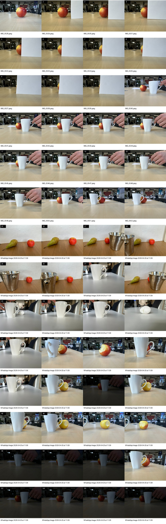

```python
display(Image(filename='data_contact_sheet_numbered.jpg'))
```

The sequence now contains:

- the original office occlusion sequence,
- new tabletop scenes with `pear`, `bucket`, and `apple`,
- white-table scenes with `cup` and `egg`,
- bright and low-light office scenes with changed viewpoint and lighting.

This matters because it lets us separate **known-category robustness** from **vocabulary flexibility**.

## Exact label-space support

```python
support_df = pd.read_csv(RESULTS_DIR / 'class_support.csv')
support_df
```

|  | class | Grounding DINO Base | YOLO11n | RT-DETRv2-R18 | Faster R-CNN ResNet50 FPN V2 |
| --- | --- | --- | --- | --- | --- |
| 0 | apple | 1 | 1 | 1 | 1 |
| 1 | cup | 1 | 1 | 1 | 1 |
| 2 | pear | 1 | 0 | 0 | 0 |
| 3 | bucket | 1 | 0 | 0 | 0 |
| 4 | egg | 1 | 0 | 0 | 0 |

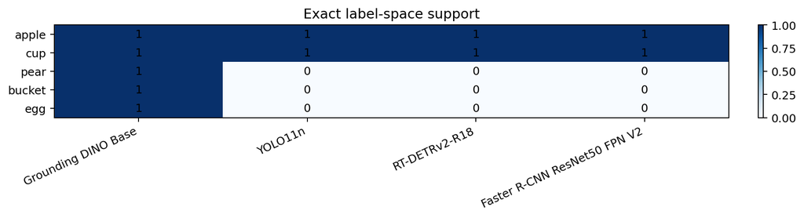

```python
display(Image(filename=str(RESULTS_DIR / 'class_support.png')))
```

This table is important for interpretation. If a model does not contain an exact class such as `pear`, `bucket`, or `egg`, then any failure on that class is a **taxonomy limitation**, not only a detector-quality issue.

## Shared-class benchmark

```python
summary_df = pd.read_csv(RESULTS_DIR / 'summary_metrics.csv')
shared_df = summary_df[summary_df['class'].isin(['apple', 'cup'])].copy()
shared_df[['model', 'class', 'frame_ap', 'precision', 'recall', 'f1', 'latency_per_image_s', 'class_supported']].sort_values(['class', 'frame_ap', 'f1'], ascending=[True, False, False])
```

|  | model | class | frame_ap | precision | recall | f1 | latency_per_image_s | class_supported |
| --- | --- | --- | --- | --- | --- | --- | --- | --- |
| 15 | Faster R-CNN ResNet50 FPN V2 | apple | 0.989124 | 0.928571 | 0.951220 | 0.939759 | 5.925093 | 1 |
| 10 | RT-DETRv2-R18 | apple | 0.980872 | 0.923077 | 0.878049 | 0.900000 | 1.199255 | 1 |
| 5 | YOLO11n | apple | 0.954742 | 0.935484 | 0.707317 | 0.805556 | 0.244460 | 1 |
| 0 | Grounding DINO Base | apple | 0.950095 | 0.820000 | 1.000000 | 0.901099 | 19.449949 | 1 |
| 16 | Faster R-CNN ResNet50 FPN V2 | cup | 1.000000 | 0.809524 | 1.000000 | 0.894737 | 5.925093 | 1 |
| 6 | YOLO11n | cup | 0.987655 | 0.829268 | 1.000000 | 0.906667 | 0.244460 | 1 |
| 11 | RT-DETRv2-R18 | cup | 0.936538 | 0.790698 | 1.000000 | 0.883117 | 1.199255 | 1 |
| 1 | Grounding DINO Base | cup | 0.837499 | 0.871795 | 1.000000 | 0.931507 | 19.449949 | 1 |

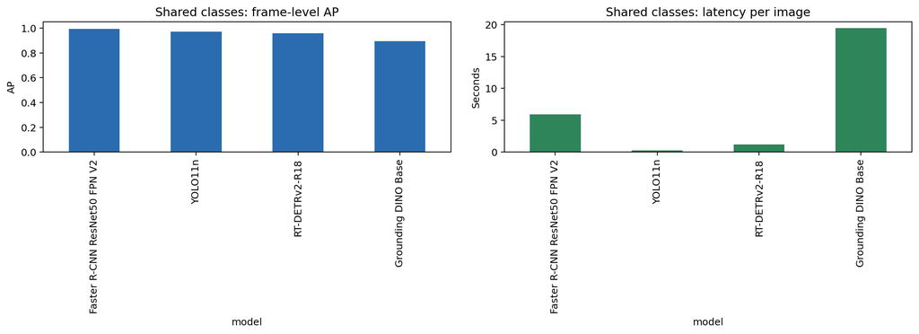

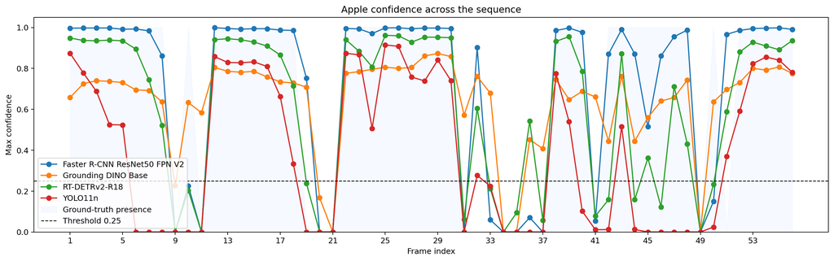

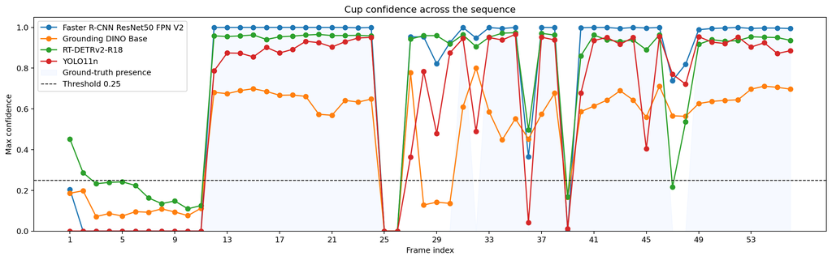

```python
display(Image(filename=str(RESULTS_DIR / 'shared_summary.png')))
display(Image(filename=str(RESULTS_DIR / 'shared_apple_trace.png')))
display(Image(filename=str(RESULTS_DIR / 'shared_cup_trace.png')))
```

### Interpretation of the shared benchmark

- This is the fairest accuracy comparison because all compared models are allowed to detect these classes.
- If a closed-vocabulary model wins here, that does **not** automatically invalidate Grounding DINO. It only means that for a **fixed known taxonomy**, a specialized detector can be more efficient.
- This section should be used to answer: *If the object list never changes, what is the best detector?*

## Novel-class stress test

```python
novel_df = summary_df[summary_df['class'].isin(['pear', 'bucket', 'egg'])].copy()
novel_df[['model', 'class', 'frame_ap', 'precision', 'recall', 'f1', 'latency_per_image_s', 'class_supported']].sort_values(['class', 'frame_ap', 'f1'], ascending=[True, False, False])
```

|  | model | class | frame_ap | precision | recall | f1 | latency_per_image_s | class_supported |
| --- | --- | --- | --- | --- | --- | --- | --- | --- |
| 3 | Grounding DINO Base | bucket | 1.000000 | 0.833333 | 1.0 | 0.909091 | 19.449949 | 1 |
| 8 | YOLO11n | bucket | 0.000000 | 0.000000 | 0.0 | 0.000000 | 0.244460 | 0 |
| 13 | RT-DETRv2-R18 | bucket | 0.000000 | 0.000000 | 0.0 | 0.000000 | 1.199255 | 0 |
| 18 | Faster R-CNN ResNet50 FPN V2 | bucket | 0.000000 | 0.000000 | 0.0 | 0.000000 | 5.925093 | 0 |
| 4 | Grounding DINO Base | egg | 0.507576 | 0.173913 | 1.0 | 0.296296 | 19.449949 | 1 |
| 9 | YOLO11n | egg | 0.000000 | 0.000000 | 0.0 | 0.000000 | 0.244460 | 0 |
| 14 | RT-DETRv2-R18 | egg | 0.000000 | 0.000000 | 0.0 | 0.000000 | 1.199255 | 0 |
| 19 | Faster R-CNN ResNet50 FPN V2 | egg | 0.000000 | 0.000000 | 0.0 | 0.000000 | 5.925093 | 0 |
| 2 | Grounding DINO Base | pear | 0.593742 | 0.125000 | 1.0 | 0.222222 | 19.449949 | 1 |
| 7 | YOLO11n | pear | 0.000000 | 0.000000 | 0.0 | 0.000000 | 0.244460 | 0 |
| 12 | RT-DETRv2-R18 | pear | 0.000000 | 0.000000 | 0.0 | 0.000000 | 1.199255 | 0 |
| 17 | Faster R-CNN ResNet50 FPN V2 | pear | 0.000000 | 0.000000 | 0.0 | 0.000000 | 5.925093 | 0 |

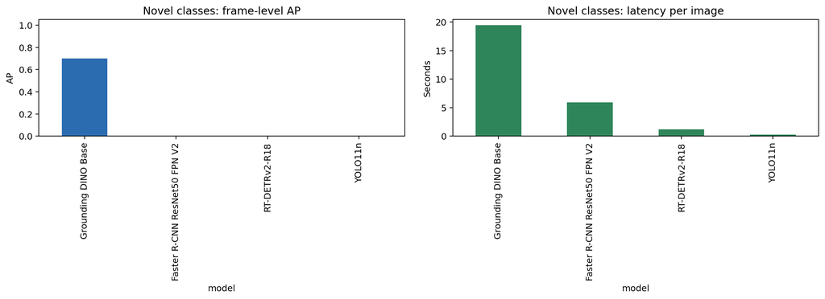

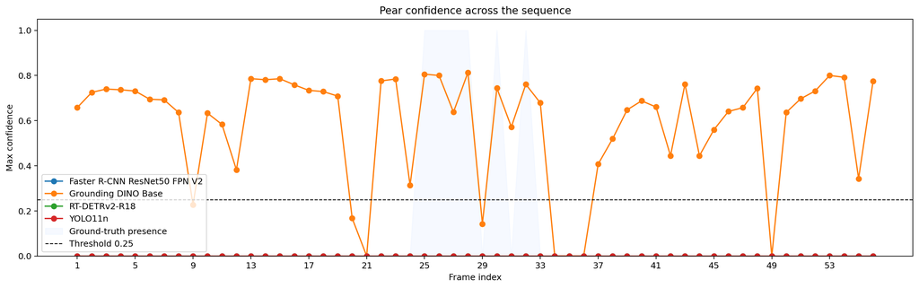

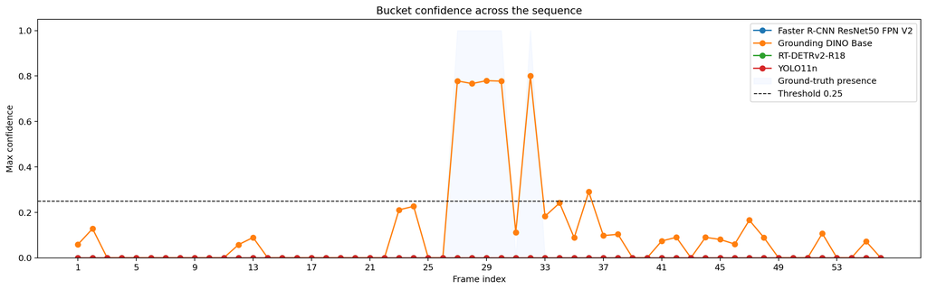

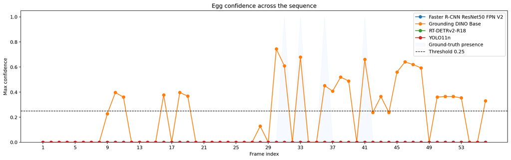

```python
display(Image(filename=str(RESULTS_DIR / 'novel_summary.png')))
display(Image(filename=str(RESULTS_DIR / 'novel_pear_trace.png')))
display(Image(filename=str(RESULTS_DIR / 'novel_bucket_trace.png')))
display(Image(filename=str(RESULTS_DIR / 'novel_egg_trace.png')))
```

### Interpretation of the novel-class stress test

- This is **not** a fair closed-vocabulary benchmark. It is a task-fit benchmark.
- The purpose is to test the exact stakeholder risk: what happens when new objects appear without retraining.
- Using proxy labels such as `sports ball`, `bowl`, or `orange` would artificially improve closed-vocabulary models while changing the semantic task, so proxies were intentionally not used.

## Final conclusion

```python
report = Path(RESULTS_DIR / 'report.md').read_text(encoding='utf-8')
display(Markdown(report))
```

Stakeholder comparison: open-vocabulary vs closed-vocabulary detectors

What this notebook tests

- A fair shared-class benchmark on `apple` and `cup`, because those classes are supported by all compared models.

- A novel-class stress test on `pear`, `bucket`, and `egg`, because these appeared in the updated data but are outside the standard COCO label space used by the closed-vocabulary baselines.

- A practical deployment trade-off: ranking quality, operational precision/recall at one threshold, and inference latency.

Why these metrics were used

- `Frame-level AP` is the primary ranking metric because we do not have bounding-box annotations. It tests whether frames containing the target object are ranked above frames that do not.

- `Precision`, `recall`, and `F1` at threshold 0.25 show the operational trade-off between false alarms and misses.

- `Latency per image` matters because a detector that wins slightly on accuracy but is much slower may be a poor deployment choice.

- Exact label-space support is reported separately, because a closed-vocabulary detector can only detect classes that exist in its pretrained taxonomy.

Critical interpretation

- Best closed-vocabulary model on the shared benchmark: **Faster R-CNN ResNet50 FPN V2**.

- Fastest model on the shared benchmark: **YOLO11n**.

- The shared benchmark tells us how well each model handles known categories under occlusion, viewpoint change, and lighting change.

- The novel-class benchmark answers a different question: what happens when the task vocabulary changes without retraining.

- A closed-vocabulary model scoring zero on `pear`, `bucket`, or `egg` is not a bug in the metric. It reflects a real deployment limitation: the requested class does not exist in the model label set.

Shared benchmark aggregate

```
csv
model,frame_ap,precision,recall,f1,latency_per_image_s

Faster R-CNN ResNet50 FPN V2,0.9946,0.869,0.9756,0.9172,5.9251

YOLO11n,0.9712,0.8824,0.8537,0.8561,0.2445

RT-DETRv2-R18,0.9587,0.8569,0.939,0.8916,1.1993

Grounding DINO Base,0.8938,0.8459,1.0,0.9163,19.4499
```

Novel-class aggregate

```
csv
model,frame_ap,precision,recall,f1,latency_per_image_s

Grounding DINO Base,0.7004,0.3774,1.0,0.4759,19.4499

Faster R-CNN ResNet50 FPN V2,0.0,0.0,0.0,0.0,5.9251

RT-DETRv2-R18,0.0,0.0,0.0,0.0,1.1993

YOLO11n,0.0,0.0,0.0,0.0,0.2445
```

Exact label-space support

```
csv
class,Grounding DINO Base,YOLO11n,RT-DETRv2-R18,Faster R-CNN ResNet50 FPN V2

apple,1,1,1,1

cup,1,1,1,1

pear,1,0,0,0

bucket,1,0,0,0

egg,1,0,0,0
```

Outcome

- If the vocabulary is fixed to a known set such as `apple` and `cup`, a closed-vocabulary detector is competitive and may even be preferable for speed.

- If the deployment requires adapting to new requested objects without retraining, the open-vocabulary reference remains the safer choice.

- This means the final recommendation depends on the real system requirement: fixed taxonomy favors a closed-vocabulary baseline, evolving task vocabulary favors Grounding DINO.

Sources

- Grounding DINO Base: https://huggingface.co/IDEA-Research/grounding-dino-base

- YOLO11n: https://docs.ultralytics.com/models/yolo11/

- RT-DETRv2-R18: https://huggingface.co/PekingU/rtdetr_v2_r18vd

- Faster R-CNN ResNet50 FPN V2: https://docs.pytorch.org/vision/master/models/generated/torchvision.models.detection.fasterrcnn_resnet50_fpn_v2.html

## Recommendation wording for the stakeholder

A careful conclusion is:

**Closed-vocabulary baselines are competitive and in some cases better on shared known classes, especially when speed matters. However, the expanded dataset shows that the deployment requirement is not a fixed closed taxonomy. Because the object list changes across scenes, the final system still benefits from an open-vocabulary detector, and Grounding DINO remains the safer choice despite the higher runtime cost.**